# horse colic 다중대응분석

by seung hoon

2020 3 5

데이터 불러오기

## 2. 다중대응분석

범주형 자료에 대한 주성분 분석으로 다중대응분석을 할 수 있었다. 범주형 자료로 사용가능한 변수는 총 12개였으며, 이를 한 플롯에 그릴 시에 해석이 복잡하므로 변수를 나눠서 플롯을 그렸 다. 단 outcome 변수는 모든 플롯에 들어가도록 했다.

### 2-1. “mucous_membrane”,“pain”,“outcome”,“surgical_lesion”

```r
library(tidyverse)
library(FactoMineR)
str(data)
```

```
## function (..., list = character(), package = NULL, lib.loc = NULL,
##     verbose = getOption("verbose"), envir = .GlobalEnv, overwrite = TRUE)
```

```r
## 여기서는 원래 그대로의 데이터를 사용했다.
## 데이터 불러오기
data = read_csv("C:/Users/SeungSeungSsi/Desktop/기말프로젝트/Horse/horse.csv")
# 데이터 타입 바꾸기
data$surgery = as.factor(data$surgery)
data$peripheral_pulse = as.factor(data$peripheral_pulse)
data$mucous_membrane = as.factor(data$mucous_membrane)
data$capillary_refill_time = as.factor(data$capillary_refill_time)
data$pain = as.factor(data$pain)
data$peristalsis = as.factor(data$peristalsis)
#data$abdomen = as.factor(data$abdomen)
data$outcome = as.factor(data$outcome)
data$surgical_lesion = as.factor(data$surgical_lesion)
#data$cp_data = as.factor(data$cp_data)
data$temp_of_extremities = as.factor(data$temp_of_extremities)
data$age = as.factor(data$age)
data$outcome = as.factor(data$outcome)
#data$lesion_location = as.factor(data$lesion_location)
#data$lesion_type = as.factor(data$lesion_type)
str(data)
```

```
## Classes 'spec_tbl_df', 'tbl_df', 'tbl' and 'data.frame': 299 obs. of  28 variables:
##  $ surgery              : Factor w/ 2 levels "no","yes": 1 2 1 2 1 1 2 2 1 1 ...
##  $ age                  : Factor w/ 2 levels "adult","young": 1 1 1 2 1 1 1 1 1 2 ...
##  $ hospital_number      : num  530101 534817 530334 5290409 530255 ...
##  $ rectal_temp          : num  38.5 39.2 38.3 39.1 37.3 NA 37.9 NA NA 38.3 ...
##  $ pulse                : num  66 88 40 164 104 NA 48 60 80 90 ...
##  $ respiratory_rate     : num  28 20 24 84 35 NA 16 NA 36 NA ...
##  $ temp_of_extremities  : Factor w/ 4 levels "cold","cool",..: 2 NA 3 1 NA 4 3 2 2 3 ...
##  $ peripheral_pulse     : Factor w/ 4 levels "absent","increased",..: 4 NA 3 3 NA 3 3 NA 1 NA ...
##  $ mucous_membrane      : Factor w/ 6 levels "bright_pink",..: NA 5 6 3 3 6 4 NA 6 4 ...
##  $ capillary_refill_time: Factor w/ 3 levels "3","less_3_sec",..: 3 2 2 3 3 2 2 2 2 2 ...
##  $ pain                 : Factor w/ 5 levels "alert","depressed",..: 3 4 4 2 NA 2 4 NA 5 3 ...
##  $ peristalsis          : Factor w/ 4 levels "absent","hypermotile",..: 1 1 3 1 NA 3 3 1 1 3 ...
##  $ abdominal_distention : chr  "severe" "slight" "none" "severe" ...
##  $ nasogastric_tube     : chr  NA NA NA "none" ...
##  $ nasogastric_reflux   : chr  NA NA NA "less_1_liter" ...
##  $ nasogastric_reflux_ph: num  NA NA NA 5 NA NA NA NA NA NA ...
##  $ rectal_exam_feces    : chr  "decreased" "absent" "normal" "decreased" ...
##  $ abdomen              : chr  "distend_large" "other" "normal" NA ...
##  $ packed_cell_volume   : num  45 50 33 48 74 NA 37 44 38 40 ...
##  $ total_protein        : num  8.4 85 6.7 7.2 7.4 NA 7 8.3 6.2 6.2 ...
##  $ abdomo_appearance    : chr  NA "cloudy" NA "serosanguious" ...
##  $ abdomo_protein       : num  NA 2 NA 5.3 NA NA NA NA NA 2.2 ...
##  $ outcome              : Factor w/ 3 levels "died","euthanized",..: 1 2 3 1 1 3 3 1 2 3 ...
##  $ surgical_lesion      : Factor w/ 2 levels "no","yes": 1 1 1 2 1 1 2 2 2 1 ...
##  $ lesion_1             : num  1130 2208 0 2208 4300 ...
##  $ lesion_2             : num  0 0 0 0 0 0 0 0 0 0 ...
##  $ lesion_3             : num  0 0 0 0 0 0 0 0 0 0 ...
##  $ cp_data              : chr  "no" "no" "yes" "yes" ...
##  - attr(*, "spec")=
##   .. cols(
##   ..   surgery = col_character(),
##   ..   age = col_character(),
##   ..   hospital_number = col_double(),
##   ..   rectal_temp = col_double(),
##   ..   pulse = col_double(),
##   ..   respiratory_rate = col_double(),
##   ..   temp_of_extremities = col_character(),
##   ..   peripheral_pulse = col_character(),
##   ..   mucous_membrane = col_character(),
##   ..   capillary_refill_time = col_character(),
##   ..   pain = col_character(),
##   ..   peristalsis = col_character(),
##   ..   abdominal_distention = col_character(),
##   ..   nasogastric_tube = col_character(),
##   ..   nasogastric_reflux = col_character(),
##   ..   nasogastric_reflux_ph = col_double(),
##   ..   rectal_exam_feces = col_character(),
##   ..   abdomen = col_character(),
##   ..   packed_cell_volume = col_double(),
##   ..   total_protein = col_double(),
##   ..   abdomo_appearance = col_character(),
##   ..   abdomo_protein = col_double(),
##   ..   outcome = col_character(),
##   ..   surgical_lesion = col_character(),
##   ..   lesion_1 = col_double(),
##   ..   lesion_2 = col_double(),
##   ..   lesion_3 = col_double(),
##   ..   cp_data = col_character()
##   .. )
```

```r
data_new <- data[,c("mucous_membrane","pain","outcome","surgical_lesion")]
str(data_new)
```

```
## Classes 'tbl_df', 'tbl' and 'data.frame':    299 obs. of  4 variables:
##  $ mucous_membrane: Factor w/ 6 levels "bright_pink",..: NA 5 6 3 3 6 4 NA 6 4 ...
##  $ pain           : Factor w/ 5 levels "alert","depressed",..: 3 4 4 2 NA 2 4 NA 5 3 ...
##  $ outcome        : Factor w/ 3 levels "died","euthanized",..: 1 2 3 1 1 3 3 1 2 3 ...
##  $ surgical_lesion: Factor w/ 2 levels "no","yes": 1 1 1 2 1 1 2 2 2 1 ...
```

```r
library(MASS)
mca.data <- mca(data_new, nf=2, abbrev=T)
mca.data
```

```
## Call:
## mca(df = data_new, nf = 2, abbrev = T)
##
## Multiple correspondence analysis of 299 cases of 4 factors
##
## Correlations 0.733 0.564  cumulative % explained 24.45 43.26
```

```r
#windows(heigh=0.05,width=0.05)
par("mar")
```

```
## [1] 5.1 4.1 4.1 2.1
```

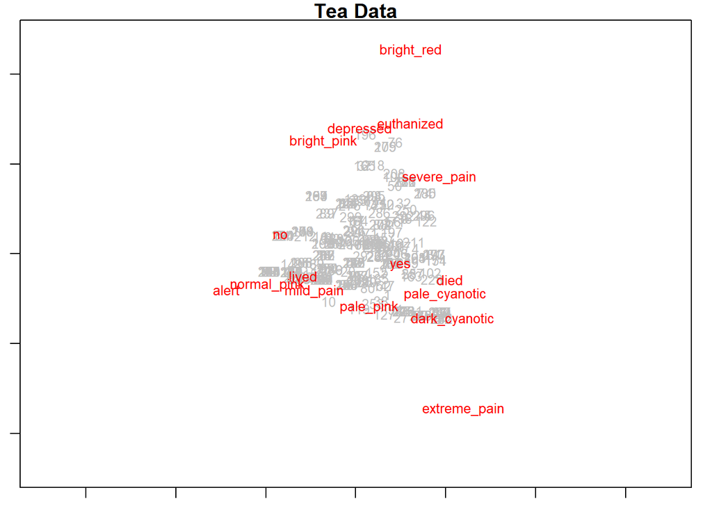

```r
par(mar=c(1,1,1,1))
plot(mca.data,cex=0.8,xlim=c(-0.05,0.05),ylim=c(-0.05,0.05),col=c("gray","red"),main="Tea Data")
```

```r
par("mar")
```

```
## [1] 5.1 4.1 4.1 2.1
```

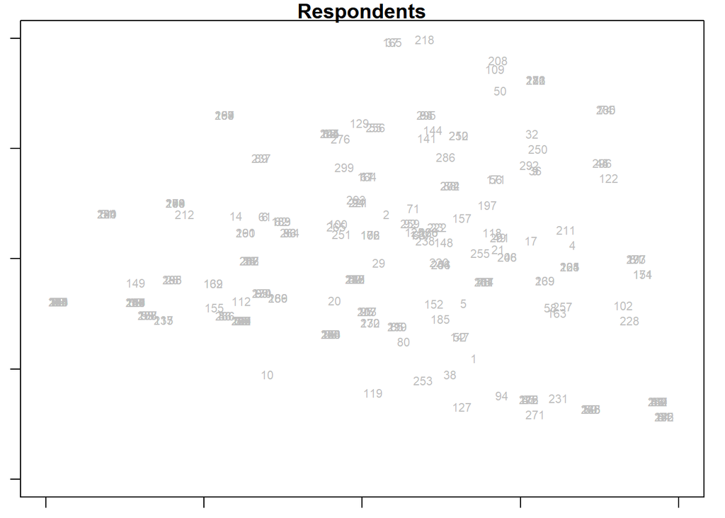

```r
par(mar=c(1,1,1,1))
plot(mca.data$rs,type="n",xlab="dim.1",ylab="dim.2",xlim=c(-0.02,0.02),ylim=c(-0.02,0.02),main="Respondents")
text(mca.data$rs,cex=0.7,col="gray")
```

```r
par("mar")
```

```
## [1] 1 1 1 1
```

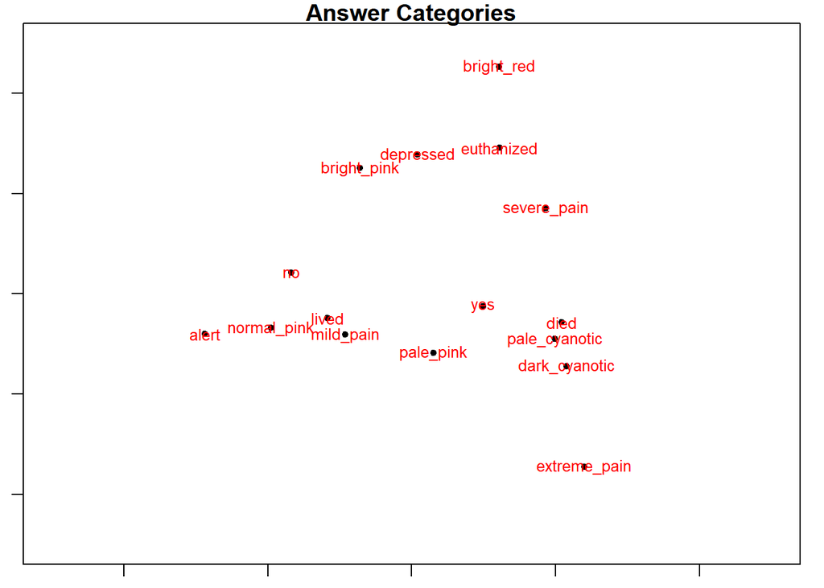

```r
par(mar=c(1,1,1,1))
plot(mca.data$cs,pch=20,xlab="dim.1",ylab="dim.2",xlim=c(-0.05,0.05),ylim=c(-0.05,0.05),main="Answer Categories")
text(mca.data$cs,rownames(mca.data$cs),cex=0.8,col="red")
```

해석 :

⚫ mucous_membrane 변수가 normal_pink일 때 surgical_leison 이 아닌 경우가 많았으며, 또한 생존하는 경우가 많은 경향이 있었다고 해석해 볼 수 있었다. 또한 mild pain을 느 낀다고 대답하는 경향이 있다는 것을 알 수 있었다.

⚫ mucous_membrane 변수가 pale_cyanotic 혹은 dark_cyanotic일 경우에 surgical_lesion이 맞다고 대답하는 경우가 많은 경향이 있었다. 또한 고통의 정도(pain)에 extreme pain 혹 은 severe_pain이라고 답하는 경우가 상대적으로 많은 연관성이 있었다. 더불어 사망하는 경우가 많았다.

⚫ Mucous_membrane 변수가 bright_red, bright_pink인 경우 안락사 당한 경우가 많았다고 해석할 수 있었다.

### 2-2. “age”, “temp_of_extremities”,“outcome”,"capillary_refill_time

```r
data_new <- data[,c("age", "temp_of_extremities","outcome","capillary_refill_time")]
str(data_new)
```

```
## Classes 'tbl_df', 'tbl' and 'data.frame':    299 obs. of  4 variables:
##  $ age                  : Factor w/ 2 levels "adult","young": 1 1 1 2 1 1 1 1 1 2 ...
##  $ temp_of_extremities  : Factor w/ 4 levels "cold","cool",..: 2 NA 3 1 NA 4 3 2 2 3 ...
##  $ outcome              : Factor w/ 3 levels "died","euthanized",..: 1 2 3 1 1 3 3 1 2 3 ...
##  $ capillary_refill_time: Factor w/ 3 levels "3","less_3_sec",..: 3 2 2 3 3 2 2 2 2 2 ...
```

```r
library(MASS)
mca.data <- mca(data_new, nf=2, abbrev=T)
mca.data
```

```
## Call:
## mca(df = data_new, nf = 2, abbrev = T)
##
## Multiple correspondence analysis of 299 cases of 4 factors
##
## Correlations 0.646 0.542  cumulative % explained 21.52 39.60
```

```r
#windows(heigh=0.05,width=0.05)
par("mar")
```

```
## [1] 5.1 4.1 4.1 2.1
```

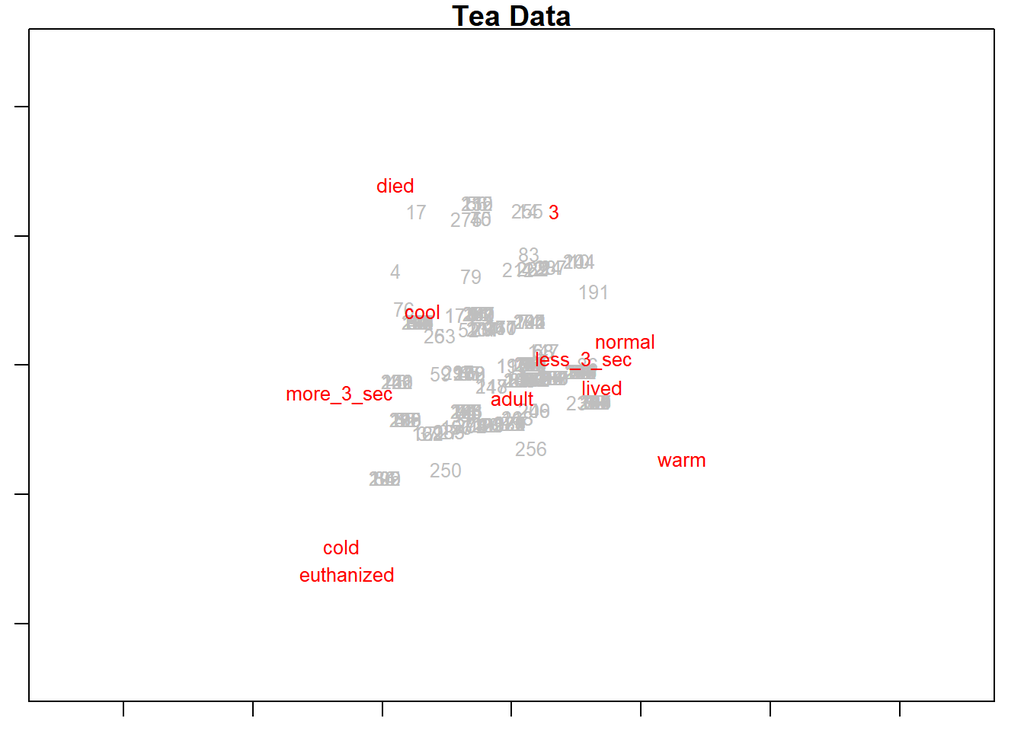

```r
par(mar=c(1,1,1,1))
plot(mca.data,cex=0.8,xlim=c(-0.05,0.05),ylim=c(-0.05,0.05),col=c("gray","red"),main="Tea Data")
```

```r
par("mar")
```

```
## [1] 1 1 1 1
```

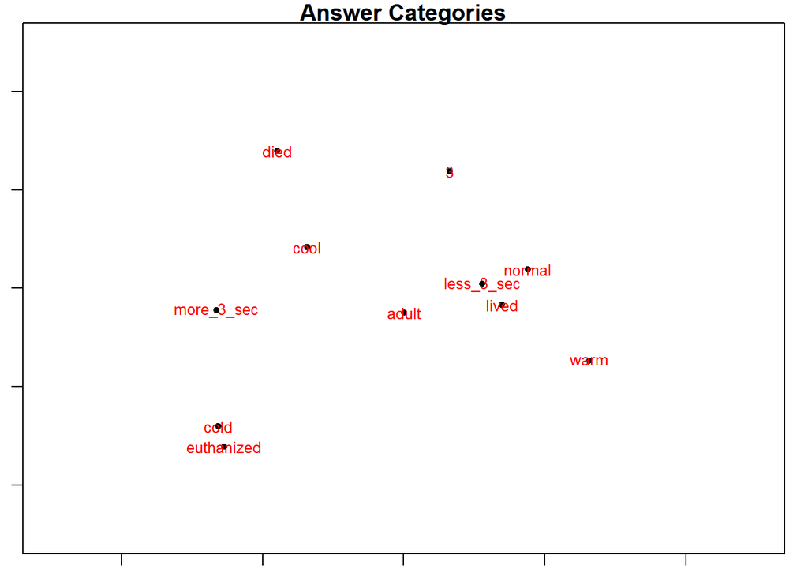

```r
par(mar=c(1,1,1,1))
plot(mca.data$cs,pch=20,xlab="dim.1",ylab="dim.2",xlim=c(-0.05,0.05),ylim=c(-0.05,0.05),main="Answer Categories")
text(mca.data$cs,rownames(mca.data$cs),cex=0.8,col="red")
```

해석:

⚫ temp_of_extremities에 cold라 답한 경우 euthanized 또한 많은 경향이 있음을 알 수 잇 었다.

⚫ temp_of_extremities에 normal 이라 답한 경우, 그리고 capillary_refill_time 이 3초 미만이 라고 답한 경우에 생존한 경우 또한 많았다.

### 2-2-3. “peripheral_pulse”, “surgery”,“outcome”,“peristalsis”

```r
data_new <- data[,c("peripheral_pulse", "surgery","outcome","peristalsis")]
str(data_new)
```

```
## Classes 'tbl_df', 'tbl' and 'data.frame':    299 obs. of  4 variables:
##  $ peripheral_pulse: Factor w/ 4 levels "absent","increased",..: 4 NA 3 3 NA 3 3 NA 1 NA ...
##  $ surgery         : Factor w/ 2 levels "no","yes": 1 2 1 2 1 1 2 2 1 1 ...
##  $ outcome         : Factor w/ 3 levels "died","euthanized",..: 1 2 3 1 1 3 3 1 2 3 ...
##  $ peristalsis     : Factor w/ 4 levels "absent","hypermotile",..: 1 1 3 1 NA 3 3 1 1 3 ...
```

```r
library(MASS)
mca.data <- mca(data_new, nf=2, abbrev=T)
mca.data$cs
```

```
##                        1             2
## absent      -0.028024959  0.0526785489
## increased    0.032949614  0.1226131247
## normal       0.017282669 -0.0057482403
## reduced     -0.018578142 -0.0036885861
## no           0.012948553  0.0019057994
## yes         -0.008990967 -0.0011878601
## died        -0.019254440 -0.0114826662
## euthanized  -0.012847149  0.0395310311
## lived        0.011069496 -0.0047315998
## absent      -0.022357029  0.0078336949
## hypermotile  0.028056219  0.0002855108
## hypomotile   0.001274645 -0.0112212737
## normal       0.023942193  0.0520843717
```

```r
#windows(heigh=0.05,width=0.05)
par("mar")
```

```
## [1] 5.1 4.1 4.1 2.1
```

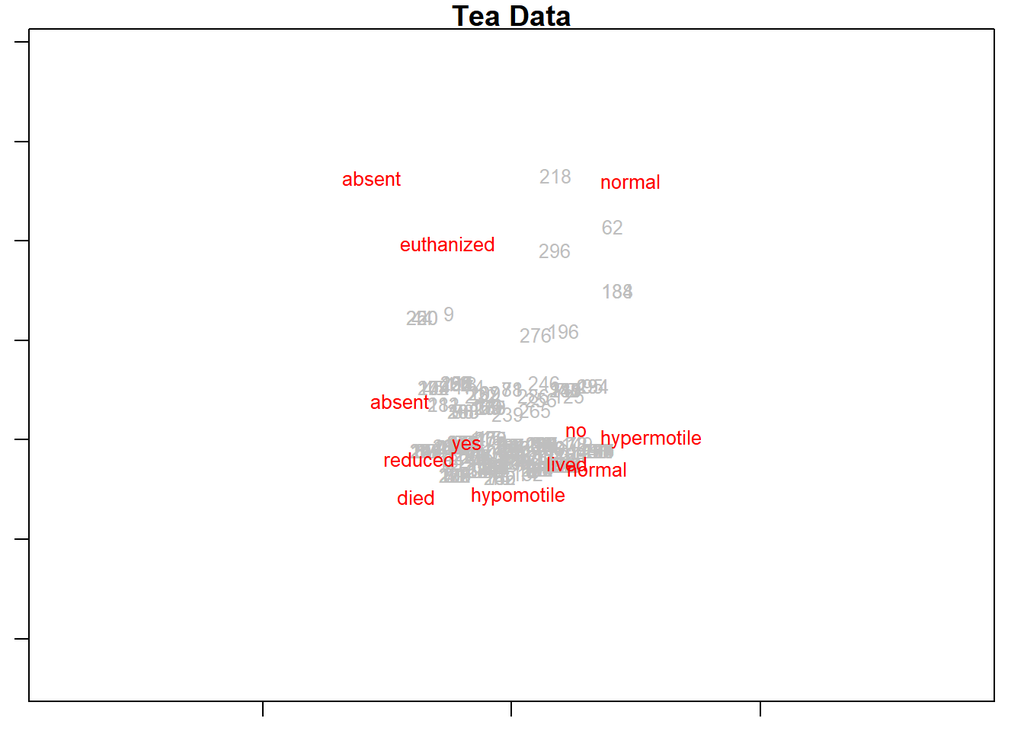

```r
par(mar=c(1,1,1,1))
plot(mca.data,cex=0.8,xlim=c(-0.05,0.05),ylim=c(-0.05,0.08),col=c("gray","red"),main="Tea Data")
```

해석 :

⚫ Peripheral_pulse 가 normal 이라고 답하고, surgery 에 no라 답하며, peristalsis가 hypermotile이라 답할 시 살아남는 경우가 많았다.